# Who does more pushups

March 8

# Introduction

Several years ago some MAT 111 students who were on the footbal team conducted a study of their team-mates. The results are contained in the data frame `pushups` in the `tigerstats` package.

```r
data(pushups)
View(pushups)
help(pushups)
```

Among other things, the students recorded the type of position a player had on the team (either line or skill), and also the number of push-ups each player could perform in a two-minute period.

Line players are on the offensive or defensive line. They need to be a certain kind of speed, but they must also be quite big and strong. Skill players do a lot of runninga and catching: they are the quarterback, running backs, receivers, etc.

Our Research Question is:

> Who does more pushups, on average: a line player or a skill player?

# Methods

We will be using a boxplot and a numerical dataset to analyze the variables.

# Results

## Graphical Results

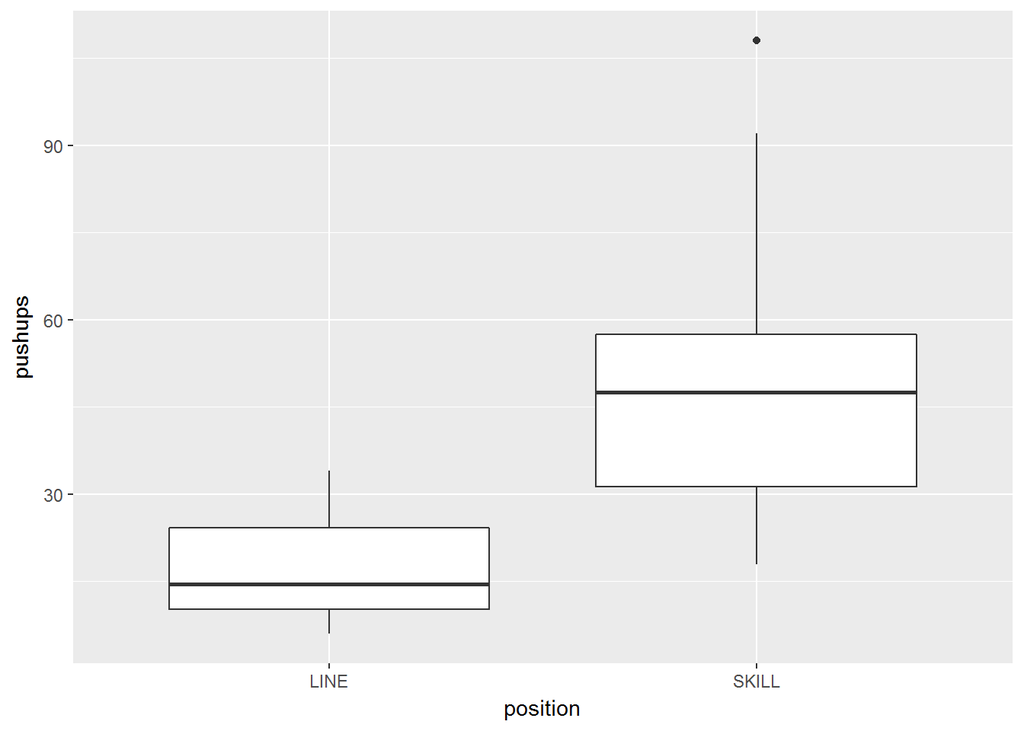

```r
a <- ggplot(pushups,aes(x=position,y=pushups))
a + geom_boxplot()
```

## Numerical Results

```r
favstats(pushups~position,data=pushups)
```

```
##   position min    Q1 median    Q3 max     mean        sd  n missing
## 1     LINE   6 10.25   14.5 24.25  34 17.12500  9.745878  8       0
## 2    SKILL  18 31.25   47.5 57.50 108 49.72727 23.036579 22       0
```

This numerical dataset shows that the skill players did more pushups than line players.

# Inferential Results

We are testing to see if skill players do more pushups than line players.

```r
t.test(pushups~position,data=pushups)
```

```
##
##  Welch Two Sample t-test
##
## data:  pushups by position
## t = -5.4341, df = 27.079, p-value = 9.421e-06
## alternative hypothesis: true difference in means is not equal to 0
## 95 percent confidence interval:
##  -44.91068 -20.29387
## sample estimates:
##  mean in group LINE mean in group SKILL
##            17.12500            49.72727
```

The mean for the line player group is 17.13 while the mean for the skill player group is 49.72, having a confidence interval of (-44.91,-20.3).

# Discussion and Conclusion

The Skills group was significantly better at doing push-ups than the line player group. We get this result with help from the box plot, the numerical dataset, and the t-test.